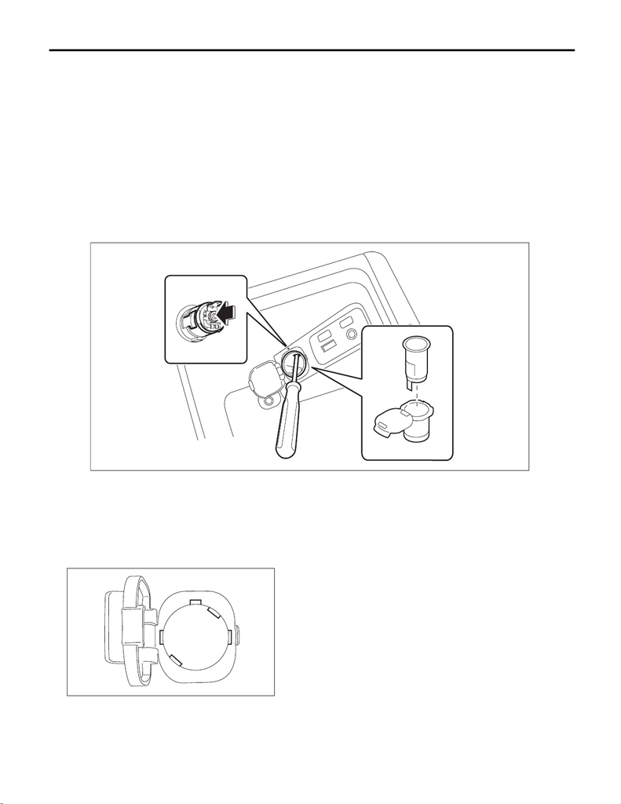

ET-25

Rear Accessory Power Supply Socket

ENTERTAINMENT

17.Rear Accessory Power Supply Socket

A: WIRING DIAGRAM

B: REMOVAL

1) Disconnect the ground cable from battery. <Ref. to NT-5, BATTERY, NOTE, Note.>

NOTE:

For models other than STI model, disconnect the ground terminal from battery sensor.

2) Remove the console box assembly. <Ref. to EI-67, REMOVAL, Console Box.>

3) Remove the socket assembly.

(1) Disconnect the connector. (STI model)

(2) While releasing the claw inside, press it in from the rear to remove the socket assembly.

(3) Remove the cap - socket.

C: INSTALLATION

1) Install the cap - socket.

2) Install the socket assembly.

NOTE:

Align the groove of the cap - socket with the claw of the socket assembly.

3) Install the console box assembly.

4) Connect the battery ground terminal. <Ref. to NT-5, BATTERY, NOTE, Note.>

NOTE:

For models other than STI model, connect the ground terminal to battery sensor.

ET-00915

ET-00916